# SAT - HW 10

Jonathan Larson, Cathy Shi

```r
# Read in and edit the data

sat_data <- read_csv('Guber1999data.csv')
# Normalize in R, transform back in Stan
sat_data <- mutate(sat_data, z_spend = as.numeric(scale(sat_data$Spend)),
                   z_ptake = as.numeric(scale(sat_data$PrcntTake)),
                   z_sat = as.numeric(scale(sat_data$SATT)))

# Create and normalize interaction variable
sat_data <- mutate(sat_data, spend_pct = Spend*PrcntTake)
sat_data <- mutate(sat_data, z_spend_pct = as.numeric(scale(Spend*PrcntTake)))
```

### General Instructions

- DO echo your R code in your output.
- Upload in your .Rmd, .stan, and .html files to Schoology. Do not zip.
- Load libraries and data in this section.
- Put the code and text in their respective sections.

### EDA

Include three scatterplots of SATT by Spend, SATT by PercntTake, and Spend by PercntTake, and comment on what you see. Calculate the correlation of Spend and PercntTake and comment on its value.

These plots show negative relationships between spending and SATT scores, and between the percentage of students who take the SAT and the average SAT score. The scatterplot of average SATT score versus percent of students who took the SAT shows a very clear negative linear relationship between percent and average score. The plot of percent taking the SAT versus spending shows a positive relationship between these two variables, which is confirmed by the correlation coefficient of $0.593$. This is a stronger correlation than between spending and SATT scores ($-0.381$).

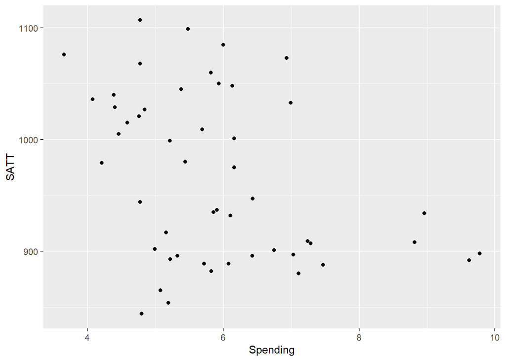

```r
ggplot(data=sat_data)+
  geom_point(mapping = aes(x=Spend,y=SATT)) + xlab("Spending")
```

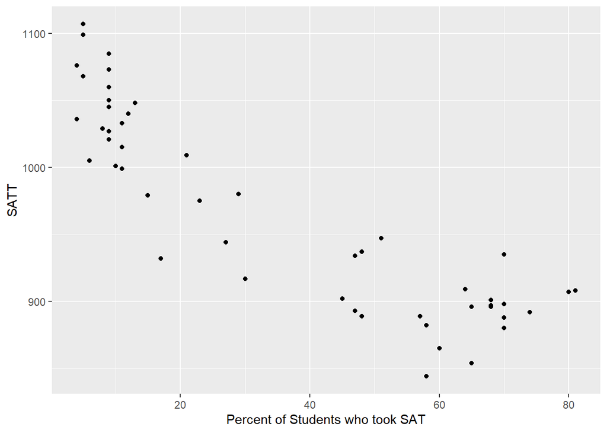

```r
# ggplot(data=sat_data)+
#   geom_point(mapping = aes(x=StuTeaRat,y=SATT))

ggplot(data=sat_data)+
  geom_point(mapping = aes(x=PrcntTake,y=SATT))+xlab("Percent of Students who took SAT")
```

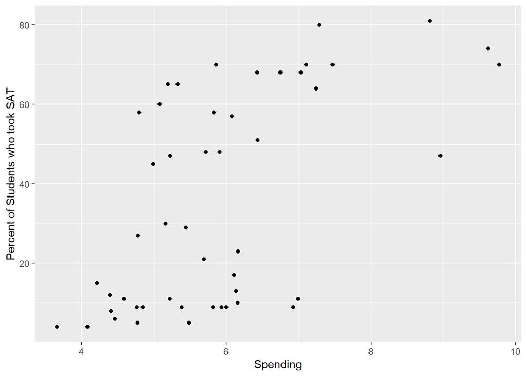

```r
# ggplot(data=sat_data)+
#   geom_point(mapping = aes(x=Salary,y=SATT))

ggplot(data=sat_data)+
  geom_point(mapping = aes(x=Spend,y=PrcntTake))+ylab("Percent of Students who took SAT")+xlab("Spending")
```

```r
corr_PctTake_Spend=cor(sat_data$Spend,sat_data$PrcntTake)
corr_SATT_Spend = cor(sat_data$Spend,sat_data$SATT)
corr_SATT_PctTake = cor(sat_data$PrcntTake,sat_data$SATT)
```

### Model Description

I’d like you to implement two models. Use a generalized $t$ distribution for both the likelihood and the priors on all of the slope parameters (code the interaction). One model does NOT use shrinkage for the slope parameters (Model 1), and one does (Model 2). Describe your two models in this section, noting the prior distributions you will use. If you know how to use Latex, please use it to write your distributions and parameters. Do not put the SAT bounds in your model, it will be hard to do prior predictive checks.

### Model 1

This model doesn’t use shrinkage. The model prior has a linear combination of $y_{i}\sim t(\nu, {\beta_{0}}+{\beta_{1}}*Spend_{i}+{\beta_{2}}*PrcntTake_{i}+\beta_{3}*Spend_{i}*PrcntTake_{i}, \sigma)$, where $i = 1,2,3,...,50$ indicating each state. The data is standardized for use in stan, and uses shape parameter $\nu \sim e^{(1/30)}$ and standardized $\sigma$ $z_\sigma \sim \frac{1}{2}Normal(0,1)$.

```r
# Input for Stan
sat.data <- list(J=3, N=nrow(sat_data),
                 mint = mean(sat_data$spend_pct),
                 mspend = mean(sat_data$Spend), mptake = mean(sat_data$PrcntTake), msat = mean(sat_data$SATT),
                 sspend = sd(sat_data$Spend),sptake = sd(sat_data$PrcntTake),ssat = sd(sat_data$SATT), sint = sd(sat_data$spend_pct),
                 z_spend = sat_data$z_spend,
                 z_ptake = sat_data$z_ptake,
                 z_int = sat_data$z_spend_pct,
                 z_sat = sat_data$z_sat)
fit.m1 <- stan(file = "model1_noshrink.stan",data = sat.data,seed = 42,control = list(adapt_delta = 0.95))
# save(fit.m1,file = "Model1.Rdata")
# load("Model1.Rdata")
# launch_shinystan(as.shinystan(fit.m1))
```

### Prior Predictive Checks

Do a prior preditive check for Model 1 that seems reasonable and explain WHY you chose it and what your visual describes. Just do a single plot, but make sure it’s clear to me that you fully understand what it is saying.

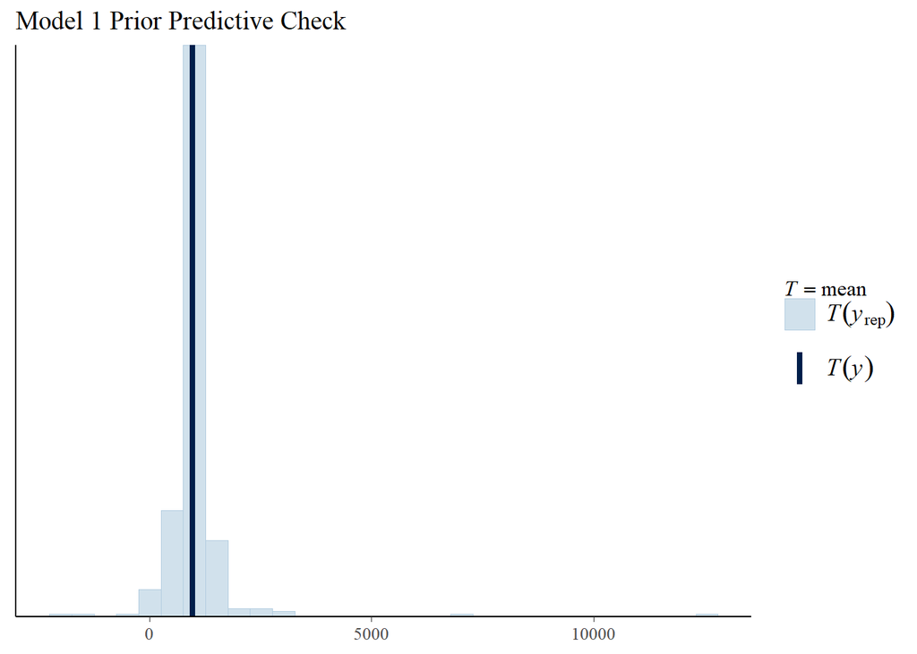

```r
# Prior Predictive Checking
sat.pri.data <- list(J=3, N=nrow(sat_data),
                     spend = sat_data$Spend,
                     ptake = sat_data$PrcntTake,
                     inter = sat_data$spend_pct,
                 mint = mean(sat_data$spend_pct),
                 mspend = mean(sat_data$Spend),
                 mptake = mean(sat_data$PrcntTake),
                 msat = mean(sat_data$SATT),
                 sspend = sd(sat_data$Spend),
                 sptake = sd(sat_data$PrcntTake),
                 ssat = sd(sat_data$SATT),
                 sint = sd(sat_data$spend_pct))

fit.prior.m1 <- stan(file = 'model1_pri_noshrink.stan', data = sat.pri.data, seed = 21,control = list(adapt_delta = 0.95))
# launch_shinystan(as.shinystan(fit.prior.m1))
#
save(fit.prior.m1,file = "Prior_fit.Rdata")
# load("prior_fit.rdata")

set.seed(21)
fake.data.stan <- as.matrix(as.data.frame(fit.prior.m1) %>% select(contains("y_fake")) %>% sample_n(size = 300))


#prior predictive check for the fake data vs. real data
ppc_stat(sat_data$SATT, fake.data.stan)+ggtitle("Model 1 Prior Predictive Check")
```

## Model 2

This model is with shrinkage. The model prior has a linear combination of $y_{i}\sim t(\nu,\beta_{0}+ {\beta_{1}} *{Spend_{i}}+ {\beta_{2}}*{PrcntTake_{i}}+{\beta_{3}}*{Spend_{i}*PrcntTake_{i}}, \sigma)$, where $i = 1,2,3,...,50$ indicating each subject. In the standardized form of this $\nu-1 \sim Exp{(1/29)}$, $z_\sigma \sim Normal(0,1)$, $z_{\beta_{0,1,2,3}}\sim student-t(1, \mu, \sigma)$ where $\mu\sim Normal(0,1)$, $\sigma\sim Gamma(2,2)$. We choose 1 for $nu$ for $z_\beta$’s because we want them to add thickness to the tails to account for outliers. We gave the standarad deviation of hyper parameters a distribution of $\sigma\sim\gamma(2,2)$.

```r
# Input for Stan, Shrinkage Model
sat.data <- list(J=3, hypers = c(2,2),
                 N=nrow(sat_data),
                 spend = sat_data$Spend,
                 ptake = sat_data$PrcntTake,
                 inter = sat_data$spend_pct,
                 mint = mean(sat_data$spend_pct),
                 mspend = mean(sat_data$Spend),
                 mptake = mean(sat_data$PrcntTake),
                 msat = mean(sat_data$SATT),
                 sspend = sd(sat_data$Spend),
                 sptake = sd(sat_data$PrcntTake),
                 ssat = sd(sat_data$SATT),
                 sint = sd(sat_data$spend_pct),
                 z_spend = sat_data$z_spend,
                 z_ptake = sat_data$z_ptake,
                 z_int = sat_data$z_spend_pct,
                 z_sat = sat_data$z_sat)
fit.m2 <- stan(file = "model2_shrink.stan",data = sat.data, seed = 42, control = list(adapt_delta = 0.95))

save(fit.m2,file = "Model2.Rdata")
# load("Model2.Rdata")
# launch_shinystan(as.shinystan(fit.m2))
```

### Hierarchical Modeling

Fit both models using the standardized data and then transform back to parameters on the original scale. We used the same hyperparameter for sigma of the betas because we assume that the $\beta_{1,2,3}$ are from the same distribution except $\beta_0$. This is because $\beta_{1,2,3}$ model the relationship between a variable and SATT scores, while $\beta_0$ is an intercept value for SATT scores. We gave the sigma hyper parameter a distribution $\sigma_h\sim\gamma(2,2)$.

### Model Diagnostics

Just write a sentence or two describing what you noticed in Shinystan when you ran the models. Remember to increase the number of digits in Stan’s output.

The $\hat{R}$’s have values well below 1.1, and the trace plots look well-mixed. This shows the chains have converged to the same values. Additionally, density plots and histograms show that the distributions for each parameter are unimodal. If this had not been the case, we would need a different model to account for bimodal distributions.

### Posterior Predictive Checks

These posterior predictive checks show that the fake data drawn from the posterior distribution resemble and include the observed data. The histogram of means shows that our posterior distribution is able to generate data with the same mean as the data we observed. This second plot shows that the posterior distribution produces data that resembles the observation.

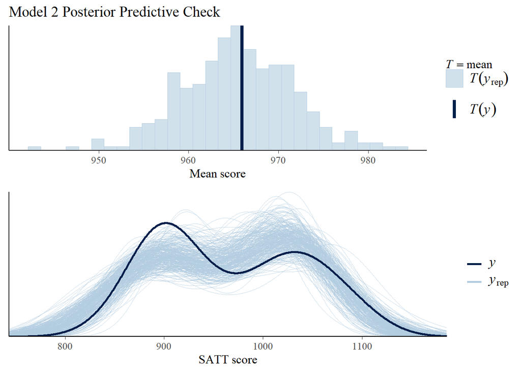

```r
# Posterior Predictive Checks
set.seed(2)

fake.data2.post.stan <- as.matrix(as.data.frame(fit.m2) %>% select(contains("y_fake")) %>% sample_n(size = 300))


# Posterior predictive check for the fake data vs. real data  (Model 2)

grid.arrange(grobs = list(
ppc_stat(sat_data$SATT, fake.data2.post.stan)+xlab("Mean score")+ggtitle("Model 2 Posterior Predictive Check"),
# ppc_stat(sat_data$SATT,stat = "max",fake.data.post.stan)+xlab("Max")+legend_none(),
ppc_dens_overlay(sat_data$SATT,fake.data2.post.stan)+xlab("SATT score")
# ,ppc_stat(sat_data$SATT,stat = "max",fake.data.post.stan)+legend_none()+xlab("Max")
))
```

### Conclusions

Answer the following questions, using credible intervals as your evidence.

1. (Model 1) Is there evidence that the slope parameters are not zero?

The $95\%$ credible intervals for $\beta_{1,2,3}$ are as follows:

- $\beta_1$: $(-12.21,17.94)$
- $\beta_2$: $(-5.53,-2.49)$
- $\beta_3$: $(-0.05, 0.45)$

Although the confidence interval for $\beta_2$ shows a negative relationship between percent of students in a state who take the SAT and the state’s mean SATT scores, there is not evidence to conclude that a relationship exists between spending and SATT scores.

2. (Model 1) What inference can you make about the effect of Spend and PercntTake on SATT? Interpret this in the context of the interaction.

This analysis shows that a state’s percentage of students who take the SAT has a negative impact on the state’s mean SATT score. It also shows that spending does not have a significant effect on scores, which our initial analysis could not predict. The connection between spending and the percentage of students who took the SAT created the appearance of a negative correlation between spending and SATT scores when this model shows that no such relationship exists.

3. How is Model 2 different from Model 1? Can you explain why? Do you have any questions about your results?

In Model 2, the results still fail to demonstrate sufficient evidence that $\beta_1$ or $\beta_3$ are not zero. However, this model’s distribution for $\beta_1$ has shifted to the right, having interval of $(-1.14,21.42)$. In addition, each of these credible intervals has shrunk. This happened because we used a hyperparameter $\sigma_h$ to enable the distribution of each $\beta$ parameter to inform the others.